# co2 data example

## Loading GPFDA package

```r
library(GPFDA)
```

## Loading co2 data

In this example, we use a real dataset and apply a customised covariance kernel.

```r
co2 <- datasets::co2
```

For visualisation purposes, we will use only the first five years of the sample.

```r
y <- co2[1:60]
n <- length(y)
input <- 5*(1:n)/n
```

We want to fit a GPR model using the observed data and then make predictions at a $1000$ equally spaced time points:

```r
inputNew <- 5*seq(1/n, 1, length.out=1000) # input test for prediction
```

## Using exponential covariance kernel

We will first fit a GPR model with a linear trend line for the mean function by setting `meanModel='t'`, and a exponential covariance function by setting `Cov='pow.ex'` and `gamma=1`.

```r
set.seed(789)
fit1 <- gpr(input=input, response=y, Cov='pow.ex', gamma=1, meanModel='t',
                      nInitCandidates=50, trace=2)
```

```r
sapply(fit1$hyper, exp)
```

```
#>  pow.ex.v  pow.ex.w        vv
#> 3.432e+00 2.444e+00 2.794e-09
```

Since the noise variance `vv` estimate is extremely low, this fitted model basically interpolates the datapoints:

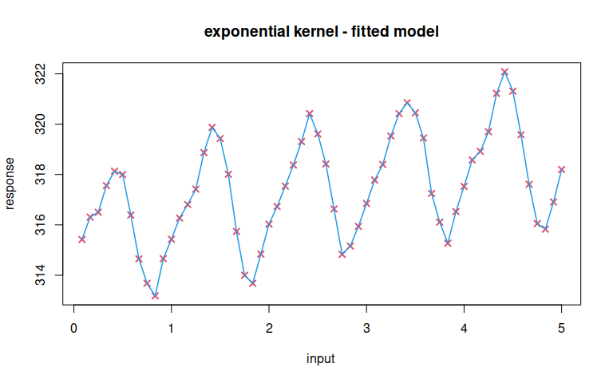

```r
plot(fit1, main="exponential kernel - fitted model")
```

See below the large uncertainty in predictions for test input points:

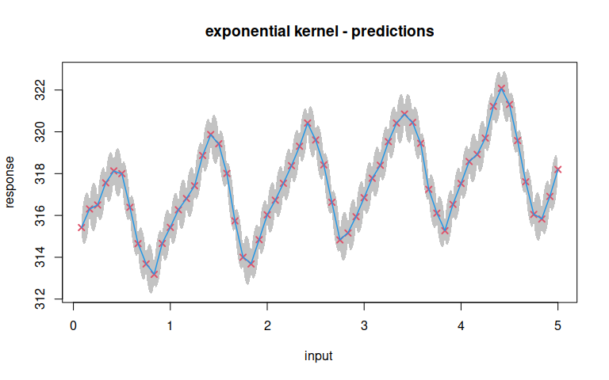

```r
pred1 <- gprPredict(train = fit1, inputNew=inputNew)
plot(pred1, main="exponential kernel - predictions")
```

These results suggest that the exponential kernel is likely not to be the best choice. A kernel which takes into account a periodic pattern may be wanted.

## Using a customised covariance kernel

To capture the periodic pattern, we use the following covariance function:
$$\begin{equation}
k(t,t')=v \exp(-w (t-t')^2 - u \sin^2(\pi (t-t'))), \quad
v,w,u > 0
\label{cus-cov}
\end{equation}$$
(see Williams, C. K., & Rasmussen, C. E. (2006). “Gaussian Processes for Machine Learning”, the MIT press).

This is not a standard covariance kernel and is not included in the package. Therefore, we will define it manually.

### Defining a customised covariance kernel

The first step is to define the covariance kernel itself. The name of the kernel must be constituted by the prefix `cov.` and 6 letters ( e.g., `cov.custom`).

Here the C++ function `distMat` is used to calculate distances $\exp(w)(t-t')^2$. The similar `distMatSq` function is used when `t` and `t'` are identical. See package documentation for more details.

```r
cov.custom <- function(hyper, input, inputNew=NULL){
  hyper <- lapply(hyper, exp)
  if(is.null(inputNew)){
    inputNew <- as.matrix(input)
  }else{
    inputNew <- as.matrix(inputNew)
  }
  input <- as.matrix(input)
  A1 <- distMat(input=input, inputNew=inputNew, A=as.matrix(hyper$custom.w),
                        power=2)
  sept <- outer(input[,1], inputNew[,1], "-")
  A2 <- hyper$custom.u*(sin(pi*sept))^2
  customCov <- hyper$custom.v*exp(-A1-A2)
  return(customCov)
}
```

### Defining the first derivatives

The second step is to define the first derivative of the log-likelihood with respect to each of the hyperparameters of the covariance kernel.

The name of the functions should look like `Dloglik.custom.w`, where the middle affix is the custom defined name, and the last letter (i.e. `w`) names the vector of the hyperparameters.

For details about derivatives, see Shi, J. Q., and Choi, T. (2011), “Gaussian Process Regression Analysis for Functional Data”, CRC Press.

```r
Dloglik.custom.w <- function(hyper, input, AlphaQ){
  A1 <- distMatSq(input=input, A=as.matrix(exp(hyper$custom.w)), power=2)
  Dcov <- - cov.custom(hyper, input)*A1
  out <- 0.5*sum(diag(AlphaQ%*%Dcov))
  return(out)
}

Dloglik.custom.u <- function(hyper, input, AlphaQ){
  sept <- outer(input[,1], input[,1], "-")
  A2 <- exp(hyper$custom.u)*(sin(pi*sept))^2
  Dcov <- - cov.custom(hyper, input)*A2
  out <- 0.5*sum(diag(AlphaQ%*%Dcov))
  return(out)
}

Dloglik.custom.v <- function(hyper, input, AlphaQ){
  Dcov <- cov.custom(hyper, input)
  out <- 0.5*sum(diag(AlphaQ%*%Dcov))
  return(out)
}
```

### Defining the second derivatives

The third step is to define the second derivatives of the log-likelihood.

```r
D2custom.w <- function(hyper, input, inv.Q, Alpha.Q){
  Cov <- cov.custom(hyper, input)
  A1 <- distMatSq(input=input, A=as.matrix(exp(hyper$custom.w)), power=2)
  D1cov <- -Cov*A1
  D2cov <- -(D1cov + Cov)*A1
  D2c.w <- D2(D1cov, D2cov, inv.Q, Alpha.Q)
  return(D2c.w)
}

D2custom.u <- function(hyper, input, inv.Q, Alpha.Q){
  Cov <- cov.custom(hyper, input)
  sept <- outer(input[,1], input[,1], "-")
  A2 <- exp(hyper$custom.u)*(sin(pi*sept))^2
  D1cov <- - Cov*A2
  D2cov <- -(D1cov + Cov)*A2
  D2c.u <- D2(D1cov, D2cov, inv.Q, Alpha.Q)
  return(D2c.u)
}

D2custom.v <- function(hyper, input, inv.Q, Alpha.Q){
  out <- cov.custom(hyper, input)
  return(out)
}
```

### Defining a diagonal matrix including the signal variance

Finally, we define a function to calculate a diagonal matrix contanining the variance of the customised covariance function. This is used for making predictions at new input points.

```r
diag.custom <- function(hyper, input){
  Qstar <- rep(exp(hyper$custom.v), nrow(input))
  return(Qstar)
}
```

### Fitting the GPR model with the customised kernel and making predictions

```r
fit2 <- gpr(input=input, response=y, Cov='custom',
            NewHyper=c('custom.w','custom.u','custom.v'), gamma=2, meanModel='t',
            nInitCandidates=50, trace=2, useGradient = F)
```

```r
sapply(fit2$hyper, exp)
```

```
#>   custom.u   custom.v   custom.w         vv
#>  0.4299023 15.4127823  0.0009464  0.0677307
```

Note that now the noise variance `vv` estimate is no longer so small. Both the fitted model and the predictions seem much more reasonable for this dataset:

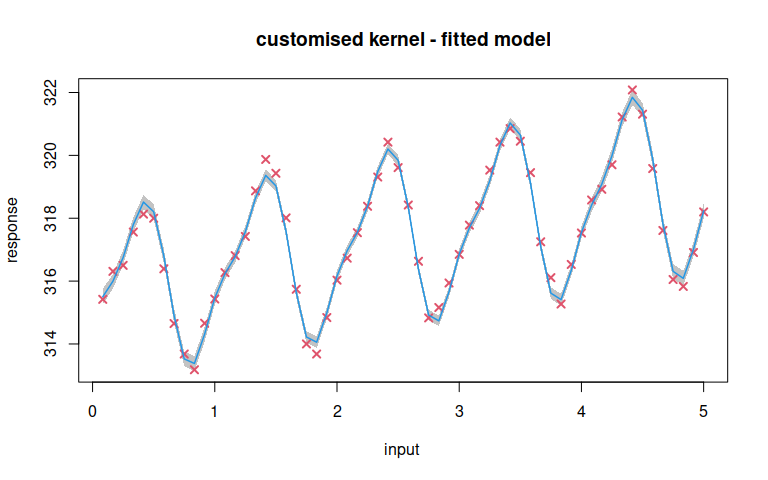

```
#> Predicted values not found, ploting fitted values
```

```r
plot(fit2, main="customised kernel - fitted model")
```

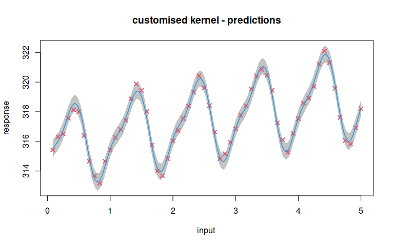

```r
pred2 <- gprPredict(train = fit2, inputNew=inputNew)
plot(pred2, main="customised kernel - predictions")
```